# Analysis of J-code claims data

### Getting started with a bit of setup

I first setup large figures for maximum visibility and I install packages required for the analysis.

```r
#Make large figures with good resolution and Install the required packages
opts_chunk$set(out.width='1000px', dpi=200,comment=NA); list.of.packages = c("caret","rpart","rpart.plot","e1071")
new.packages = list.of.packages[!(list.of.packages %in% installed.packages()[,"Package"])];
if(length(new.packages)) install.packages(new.packages)
```

### 1. Load the dataset and analyse the J-code claim lines

The dataset “claim.sample.csv” must be in the following path : “~/Desktop/data/claim.sample.csv”. The dataset is loaded here and the blank entries (missing data) are filled with NA. J-code claims are defined as claims that have a “Procedure.Code” attribute that starts with the letter “j” (case-insensitive) and J-code claims are extracted from the original dataset.

```r
#set datapath, load dataset and extract J-code claim lines
dataset = read.table('~/Desktop/data/claim.sample.csv',sep=',',header=T,na.strings=c('NA',''))
jclaims = droplevels(dataset[grep("^[jJ]", dataset$Procedure.Code),])
```

#### 1.A - The number of J-code claim lines is :

```r
nrow(jclaims)
```

```
[1] 51029
```

#### 1.B - The total amount paid for in-network J-code claims to providers is :

```r
paste0("$",sum(jclaims[jclaims$In.Out.Of.Network=="I",]$Provider.Payment.Amount))
```

```
[1] "$2417220.959115"
```

#### 1.C - The top five J-code claims based on the payments to providers are :

```r
#calculate total paid per J-code claim and display top 5
PaidByJclaim = setNames(aggregate(jclaims$Provider.Payment.Amount,by=list(jclaims$Procedure.Code),FUN=sum,na.rm=TRUE),c('j-code','total.paid'))
head(PaidByJclaim[order(PaidByJclaim$total.paid,decreasing=T),],n=5)
```

```
    j-code total.paid
78   J1745  434232.08
8    J0180  299776.56
200  J9310  168630.87
148  J3490   90249.91
73   J1644   81909.40
```

### 2. The number of providers that were paid for at least one J-code claim line is :

```r
jclaimsPaid = droplevels(jclaims[jclaims$Provider.Payment.Amount>0,])
nlevels(jclaimsPaid$Provider.ID)
```

```
[1] 13
```

Those providers are :

```r
levels(jclaimsPaid$Provider.ID)
```

```
 [1] "FA0001387001" "FA0001387002" "FA0001389001" "FA0001389003"
 [5] "FA0001411001" "FA0001411003" "FA0001774001" "FA0004551001"
 [9] "FA1000014001" "FA1000014002" "FA1000015001" "FA1000015002"
[13] "FA1000016001"
```

#### 2.A - Scatter plot that displays the number of denied vs. paid claims for each of these providers

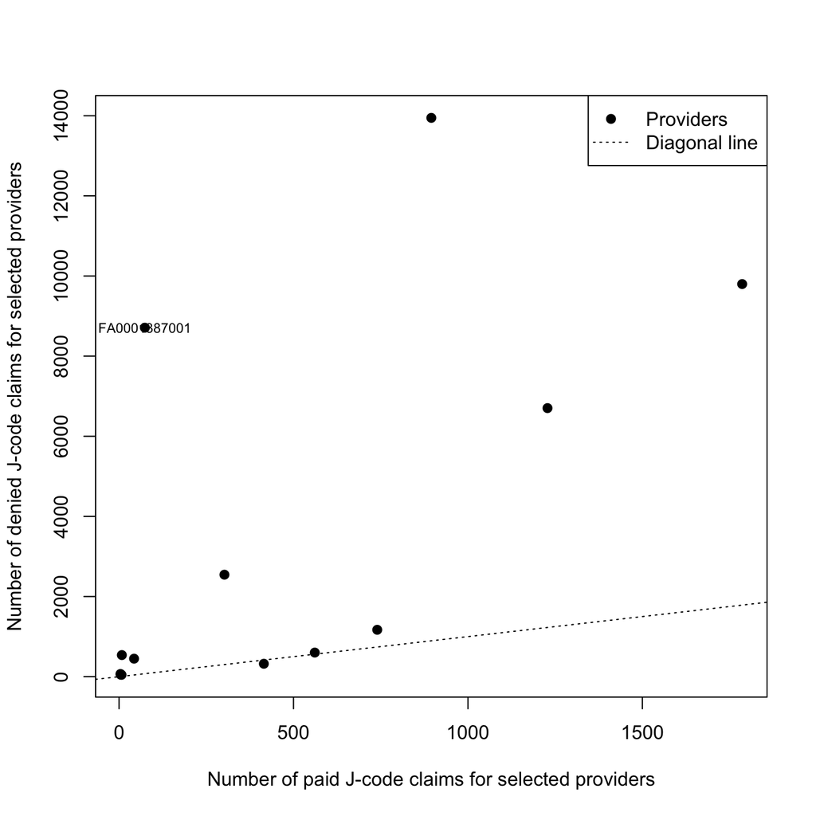

```r
#get the j-code claims of these 13 providers
jclaimsProvdMoreThan1Jpaid = droplevels(jclaims[jclaims$Provider.ID %in% levels(jclaimsPaid$Provider.ID),])
#calculate number of j-code claims denied,paid for each of these providers
denied = aggregate(jclaimsProvdMoreThan1Jpaid$Provider.Payment.Amount==0,by=list(jclaimsProvdMoreThan1Jpaid$Provider.ID),FUN=sum,na.rm=TRUE)
paid = aggregate(jclaimsProvdMoreThan1Jpaid$Provider.Payment.Amount>0,by=list(jclaimsProvdMoreThan1Jpaid$Provider.ID),FUN=sum,na.rm=TRUE)
#scatter plot
plot(paid$x,denied$x,xlab='Number of paid J-code claims for selected providers',ylab='Number of denied J-code claims for selected providers',pch=19)
#locate concerning provider
text(paid$x[1],denied$x[1],labels=denied$Group.1[1],cex= 0.7, offset = 10)
abline(0,1,lty=c(3),col='black')
legend("topright",c("Providers","Diagonal line"),
    pch = c(19,NA),lty=c(NA,3),col=c("black","black"))
```

#### 2.C - Based on the graph, is the behavior of any of the providers concerning? Explain.

```r
levels(denied$Group.1)[1]
```

```
[1] "FA0001387001"
```

### 3. Consider all claim lines with a J-code.

#### 3.A - What percentage of J-code claim lines were denied?

```r
paste0(sum(jclaims$Provider.Payment.Amount==0)/nrow(jclaims)*100,'%')
```

```
[1] "88.1087224911325%"
```

#### 3.B - Modeling

I created a model to predict when a J-code claim is denied. I chose classification decision tree as a modeling approach because :

- Predicting whether a claim is denied or not is a binary classification task.
- This is something the simple logistic regression classifier can do but here the data attributes are not all numerical; some are categorical. This is a case that a classification tree or a naive Bayes Classifier can deal with as they can work with both data types.
- The Bayes naive classifier is appropriate when factors can be assumed to be independent from each other which is not a reasonable assumption here. The data attributes have an “and” relationship with each others and most likely interact with the denial status in an “if-then” fashion which is consistent with how decision trees works. For example, “if” a patient is diagnosed for a disease that is covered by the insurance “and if” the patient was treated “in-network” then the claim might be paid.
- The decision tree automatically selects the attributes that influence the outcome predictions. Those are the top few nodes on which the tree is split.
- The decision tree is robust to the presence of missing data which our dataset has :

```r
sum(is.na(jclaims))
```

```
[1] 85543
```

- The decision tree offers a more intuitive understanding of the decision-making process that leads to claim denial.

#### Create the dataset used for modeling

I calculated a denial status for each claim (denied (labelled 1) if Provider.Payment.Amount==0, paid (labelled 0)if Provider.Payment.Amount>0) and added that outcome variable to the j-codes dataset for modeling

```r
jToModel = jclaims
jToModel$denialStatus = NA
#denied claims are labelled "1", paid "0" and denial status is added to the dataset
jToModel$denialStatus[jToModel$Provider.Payment.Amount==0]=1
jToModel$denialStatus[jToModel$Provider.Payment.Amount>0]=0
jToModel$denialStatus = as.factor(jToModel$denialStatus)
```

#### Make sense of dataset variables and prepare for modeling

I removed from that dataset all the factors that :

- are most likely not predictors : “X”,“Claim.Number”, “Reference.Index”, “Claim.Line.Number”
- depend on the denial status : “Denial.Reason.Code” is removed because the insurer/payer probably needs a model that will help it assign a denial status to each claim. In that case “Denial.Reason.Code” which is an attribute that is probably available only after the denial decision will not be available in new test data.
- that directly contributed to calculate the denial status : “Provider.Payment.Amount”. Keeping that variable among the predictors automatically produces spurious classification accuracy of 100% as used to calculate the denial status.

```r
jToModel[,c("Provider.Payment.Amount","X","Claim.Number", "Reference.Index", "Claim.Line.Number","Denial.Reason.Code")] = NULL
```

```r
#convert the following attributes to factors and display the dataset data types
toFactor = c("Place.Of.Service.Code", "Member.ID","Subscriber.Index","Claim.Current.Status","Line.Of.Business.ID","Group.Index","Subgroup.Index")
jToModel[toFactor] <- lapply(jToModel[toFactor], function(x) as.factor(as.numeric(x)))
unique(sapply(jToModel,class))
```

```
[1] "factor"  "numeric"
```

The dataset for modeling thus contains the following predictor attributes :

```r
predictors = setdiff(colnames(jToModel),c("denialStatus"))
predictors
```

```
 [1] "Member.ID"                 "Provider.ID"
 [3] "Line.Of.Business.ID"       "Revenue.Code"
 [5] "Service.Code"              "Place.Of.Service.Code"
 [7] "Procedure.Code"            "Diagnosis.Code"
 [9] "Claim.Charge.Amount"       "Price.Index"
[11] "In.Out.Of.Network"         "Pricing.Index"
[13] "Capitation.Index"          "Subscriber.Payment.Amount"
[15] "Group.Index"               "Subscriber.Index"
[17] "Subgroup.Index"            "Claim.Type"
[19] "Claim.Subscriber.Type"     "Claim.Pre.Prince.Index"
[21] "Claim.Current.Status"      "Network.ID"
[23] "Agreement.ID"
```

##### Build a simple tree model (pruned) that generalizes well (cross-validated)

One key disadvantage of decision trees is that they tend to overfit the data they are trained on leading to poor generalization performance (predicting accuracy) on new test datasets. So I cross-validated the model by first splitting the dataset into 90% train and 10% test subsets , and by then splitting the train dataset into 90% train and 10% validation subsets. The model was trained on that train subset and validated by checking how well its predicting accuracy generalized to the validation subset.

```r
library('caret')
set.seed(729376)
#split train-test
ix = createDataPartition(jToModel$denialStatus,p=0.9,list=FALSE)
jTrainAll = jToModel[ix,]
jTest = jToModel[-ix,]
#split train-validation
ix = createDataPartition(jTrainAll$denialStatus,p=0.9,list=FALSE)
jTrain = jTrainAll[ix,]
jval = jTrainAll[-ix,]
```

I used the train dataset to build the model.

```r
library('rpart'); library(rpart.plot)
tmodel = rpart(formula=denialStatus~.,data=jTrain,method='class',control=rpart.control(minsplit=10, cp=0))
```

I selected the decision tree size that minimized the cross-validated error rate produced from training.

```r
#get tree depth parameter that minimizes cross-validated error rate and use to prune tree
bestcp <- tmodel$cptable[which.min(tmodel$cptable[,"xerror"]),"CP"]
tmodel.pruned <- prune(tmodel, cp = bestcp)
```

The decision tree will be very difficult to visualize because many of the categorical attributes have lots of levels as you can see below :

```r
categPred = predictors[sapply(jToModel[,predictors],class) %in% c('factor')]
numPred = predictors[sapply(jToModel[,predictors],class) %in% c('numeric','integer')]
sapply(jToModel[,categPred],nlevels)
```

```
             Member.ID            Provider.ID    Line.Of.Business.ID
                  6341                     15                      5
          Revenue.Code           Service.Code  Place.Of.Service.Code
                    11                     12                      1
        Procedure.Code         Diagnosis.Code            Price.Index
                   202                   1438                      3
     In.Out.Of.Network          Pricing.Index       Capitation.Index
                     3                      4                      3
           Group.Index       Subscriber.Index         Subgroup.Index
                   781                   6243                    790
            Claim.Type  Claim.Subscriber.Type Claim.Pre.Prince.Index
                     2                      2                      3
  Claim.Current.Status             Network.ID           Agreement.ID
                     9                     15                     22
```

The decision tree would look something like that :

[figure not shown]

```r
#split the labels at the branches into multiple line for visibility
split.fun <- function(x, labs, digits, varlen, faclen){
    labs <- gsub(",", " ", labs);
    for(i in 1:length(labs)){
        labs[i] <- paste(strwrap(labs[i], width=25), collapse="\n")};
    labs;
    }
par(xpd=TRUE)
#plot the tree
prp(tmodel.pruned,type=3,cex=0.1,varlen=3,faclen=3,split.fun= split.fun,
    box.col=c("red", "green"),extra = 0,
    branch=1,add.labs=TRUE,branch.lty=1,branch.lwd=3)
legend("bottomleft", legend = c("denied","paid"), fill = c("red", "green"),
       title = "Group")
```

which is impossible to read.

#### 3.C - How accurate is your model at predicting denied claims?

Model accuracy is the most common performance metric: The model predicted denial status correctly 96.9% of the time on a test dataset — better than chance (50%). However in the dataset, 88% of the claims are denied, so guessing “denied” all the time would be 88% accurate but not useful for our unbalanced dataset. But we can still see that our model performs better than chance and does better than the simplest guessing model consisting in always predicting “denied” (a lower bound on performance).

- The accuracies of a model based on the numerical factors are, for the train, validation and test sets : The accuracies are better than for a simple constant prediction model (88%), and remain high (a small drop) between the training, validation and test dataset, thus the model generalizes well (overfit only a little):

```r
#accuracy on training, validation and test subset
accTr=sum(predict(tmodel.pruned,newdata=jTrain,type='class')==jTrain[,"denialStatus"])/nrow(jTrain)*100
accVa=sum(predict(tmodel.pruned,newdata=jval,type='class')==jval[,"denialStatus"])/nrow(jval)*100
accTe=sum(predict(tmodel.pruned,newdata=jTest,type='class')==jTest[,"denialStatus"])/nrow(jTest)*100
cat(accTr,"% accuracy on train\n",accVa,"% accuracy on validation\n",accTe,"% accuracy on test\n")
```

```
99.30325 % accuracy on train
 97.45209 % accuracy on validation
 96.98158 % accuracy on test
```

What matters to the business is probably the proportion of claims that the model failed to correctly deny because misses lead to overpayments. Thus the model recall (denied claims found by the model) must be high and the number of misses or false negatives must be low which are conditions that are satisfied by the model

- 98% of the claims predicted as denied were actually denied (high precision)
- 98.6% of the denied claims were found by the model (high recall) and 1.4% were missed

```r
#calculate confusion matrix, model precision and recall
confmatrix = table(jTest$denialStatus,predict(tmodel.pruned,newdata=jTest,type='class'))
precision = confmatrix[2,2]/sum(confmatrix[,2])
recall = confmatrix[2,2]/sum(confmatrix[2,])
paste0(precision, "% precision")
```

```
[1] "0.980309734513274% precision"
```

```r
paste0(recall, "% recall")
```

```
[1] "0.985542704626335% recall"
```

We can also check that the confusion matrix has enough sample of all cases and nothing weird that would prevent interpretation of the recall and precision. As you can see below, the sample size are ok.

```r
#annotate confusion matrix and display
rownames(confmatrix)=c("paid","denied")
colnames(confmatrix)=c("predicted paid","predicted denied")
confmatrix
```

```
         predicted paid predicted denied
  paid              517               89
  denied             65             4431
```

#### 3.D - What data attributes are predominately influencing the denial rate?

The decision tree automatically selects 10 attributes that predominately influence the error rate and thus prediction accuracy. Those 10 attributes are stated below under “Variables actually used in tree construction”:

```r
printcp(tmodel.pruned)
```

```
Classification tree:
rpart(formula = denialStatus ~ ., data = jTrain, method = "class",
    control = rpart.control(minsplit = 10, cp = 0))

Variables actually used in tree construction:
 [1] Agreement.ID         Claim.Charge.Amount  Claim.Current.Status
 [4] Diagnosis.Code       Member.ID            Price.Index
 [7] Procedure.Code       Provider.ID          Revenue.Code
[10] Service.Code

Root node error: 4916/41335 = 0.11893

n= 41335

           CP nsplit rel error  xerror      xstd
```

[output cut: 44 more lines]

### Conclusion

The dataset analysed probably comes from an health insurer that would like a solution to decide when a claim must be paid or denied with high precision. Such solution would allow them to reduce overpayments that result from paying claims that should have been denied.

I analysed J-code claim lines which I assume stand for CMS codes for “injected drugs & chemotherapy”.

The analysis revealed that ten attributes contribute to the decision to deny or accept a J-code claim : (“Agreement.ID”, “Claim.Charge.Amount”, “Claim.Current.Status”,“Diagnosis.Code”, “Member.ID”,“Price.Index”,“Procedure.Code”,“Provider.ID”,“Revenue.Code”,“Service.Code” Using those attribute in a decision tree can predict the denial status of a claim with high accuracy (96%), produce a precision in predicting denied claims of 98% and a recall (98.6%) which means 1.4% of overpayment. A better model can probably be built to reduce overpayment if 1.4% is still too high for the business.

One concern is that decision tree models can be biased toward data attributes that have many levels. This is the case for many of the categorical data attributes, which the model can potentially be improved by taking care of this issue. One can for example better balance the dataset by pruning the very rare levels of some attributes. Another way is to do dimensionality reduction to find features that are discriminative before hand,